# Lab 1: Intro to R

Kenan Sooklall

2021-02-17

```r
library(tidyverse)
library(openintro)
```

### Exercise 1

```r
arbuthnot$girls
```

```
##  [1] 4683 4457 4102 4590 4839 4820 4928 4605 4457 4952 4784 5332 5200 4910 4617
## [16] 3997 3919 3395 3536 3181 2746 2722 2840 2908 2959 3179 3349 3382 3289 3013
## [31] 2781 3247 4107 4803 4881 5681 4858 4319 5322 5560 5829 5719 6061 6120 5822
## [46] 5738 5717 5847 6203 6033 6041 6299 6533 6744 7158 7127 7246 7119 7214 7101
## [61] 7167 7302 7392 7316 7483 6647 6713 7229 7767 7626 7452 7061 7514 7656 7683
## [76] 5738 7779 7417 7687 7623 7380 7288
```

### Exercise 2

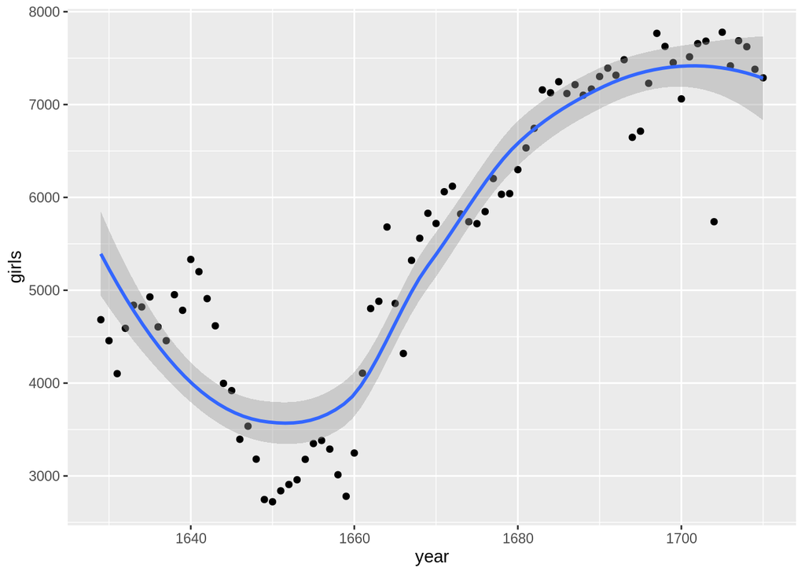

```r
ggplot(data = arbuthnot, aes(x = year, y = girls)) +
  geom_point() +  geom_smooth()
```

Is there an apparent trend in the number of girls baptized over the years? How would you describe it? (To ensure that your lab report is comprehensive, be sure to include the code needed to make the plot as well as your written interpretation.)

- The plot is showing an increase in the number of girls being baptized from 1629 to 1710.

### Exercise 3

Now, generate a plot of the proportion of boys born over time. What do you see?

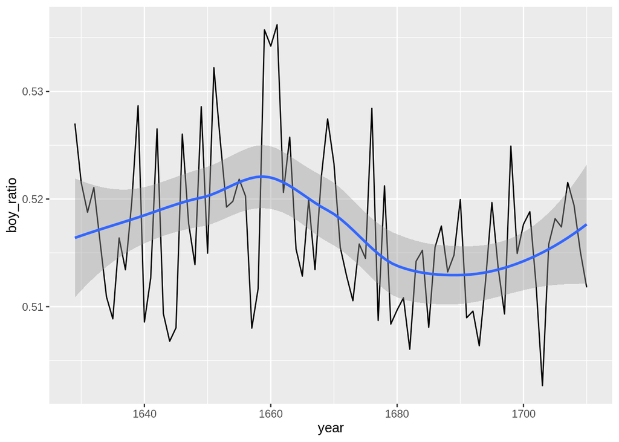

```r
arbuthnot <- arbuthnot %>%
  mutate(total = boys + girls)
arbuthnot <- arbuthnot %>%
  mutate(boy_to_girl_ratio = boys / girls)
arbuthnot <- arbuthnot %>%
  mutate(boy_ratio = boys / total)

ggplot(data = arbuthnot, aes(x = year, y = boy_ratio)) +
  geom_line() +
  geom_smooth()
```

- It looks like the proportion of boys initially went up, then dropped and then slowly rising.

### Exercise 4

What years are included in this data set? What are the dimensions of the data frame? What are the variable (column) names?

```r
glimpse(present)
```

```
## Rows: 63
## Columns: 3
## $ year  <dbl> 1940, 1941, 1942, 1943, 1944, 1945, 1946, 1947, 1948, 1949, 195…
## $ boys  <dbl> 1211684, 1289734, 1444365, 1508959, 1435301, 1404587, 1691220, …
## $ girls <dbl> 1148715, 1223693, 1364631, 1427901, 1359499, 1330869, 1597452, …
```

```r
unique(present$year)
```

```
##  [1] 1940 1941 1942 1943 1944 1945 1946 1947 1948 1949 1950 1951 1952 1953 1954
## [16] 1955 1956 1957 1958 1959 1960 1961 1962 1963 1964 1965 1966 1967 1968 1969
## [31] 1970 1971 1972 1973 1974 1975 1976 1977 1978 1979 1980 1981 1982 1983 1984
## [46] 1985 1986 1987 1988 1989 1990 1991 1992 1993 1994 1995 1996 1997 1998 1999
## [61] 2000 2001 2002
```

```r
NROW(present); NCOL(present)
```

```
## [1] 63
```

```
## [1] 3
```

- The data set is 63 rows and 3 columns (year, boys, girls) which includes years 1940 to 2002.

### Exercise 5

How do these counts compare to Arbuthnot’s? Are they of a similar magnitude?

```r
present <- present %>%
  mutate(total = boys + girls)
head(present)
```

```
## # A tibble: 6 x 4
##    year    boys   girls   total
##   <dbl>   <dbl>   <dbl>   <dbl>
## 1  1940 1211684 1148715 2360399
## 2  1941 1289734 1223693 2513427
## 3  1942 1444365 1364631 2808996
## 4  1943 1508959 1427901 2936860
## 5  1944 1435301 1359499 2794800
## 6  1945 1404587 1330869 2735456
```

- The values in present are much bigger than arbuthnot by 3 orders of magnitude

### Exercise 6

Make a plot that displays the proportion of boys born over time. What do you see? Does Arbuthnot’s observation about boys being born in greater proportion than girls hold up in the U.S.? Include the plot in your response. Hint: You should be able to reuse your code from Exercise 3 above, just replace the dataframe name.

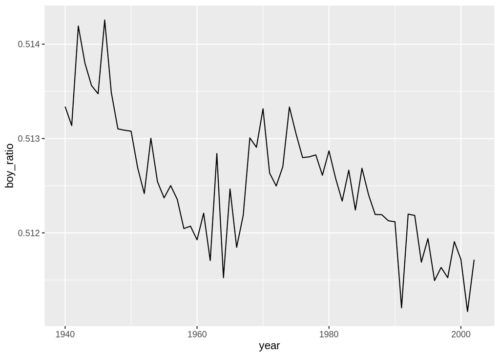

```r
present <- present %>%
  mutate(total = boys + girls)
present <- present %>%
  mutate(boy_to_girl_ratio = boys / girls)
present <- present %>%
  mutate(boy_ratio = boys / total)

ggplot(data = present, aes(x = year, y = boy_ratio)) +
  geom_line()
```

### Exercise 7

```r
# Insert code for Exercise 7 here
present[which.max(present$total), ]
```

```
## # A tibble: 1 x 6
##    year    boys   girls   total boy_to_girl_ratio boy_ratio
##   <dbl>   <dbl>   <dbl>   <dbl>             <dbl>     <dbl>
## 1  1961 2186274 2082052 4268326              1.05     0.512
```

- It looks like year 1961 had the most total number of births in the U.S at 4268326.